# Streamflow

AnnaClaire Marley

6/19/2020

This markdown analyzes streamflow gage station data in the Chuska mountains

## Investigate missing values first

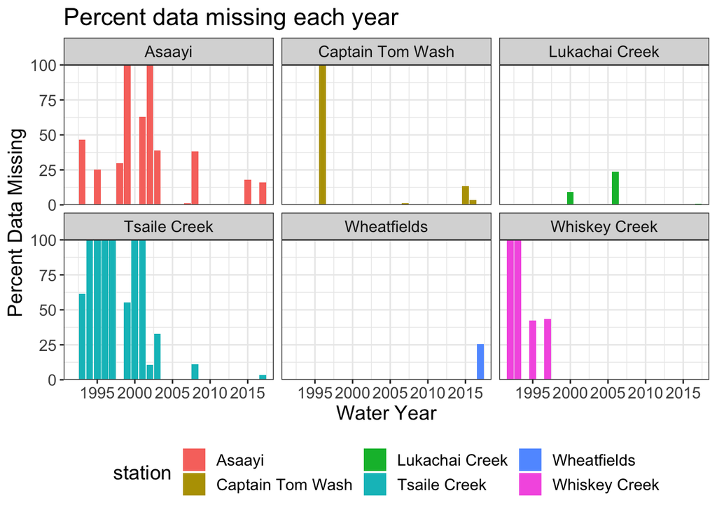

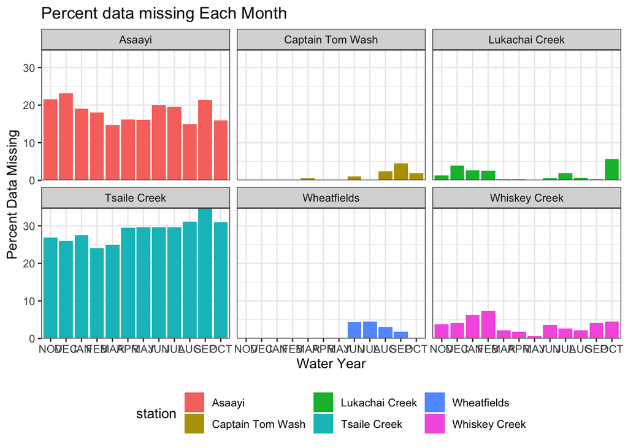

# Daily time series all stations

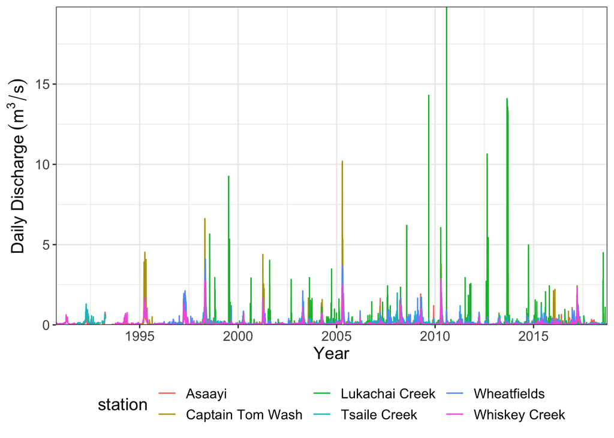

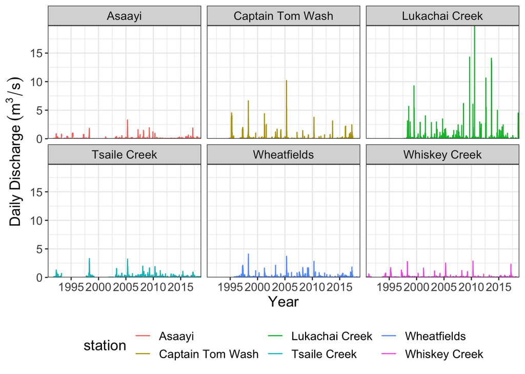

#### Observations

- Lukachai has the higest discharge, but isn’t directly in the Chuskas
- Captain Tom Wash has the next highest discharge

# Monthly peak streamflow

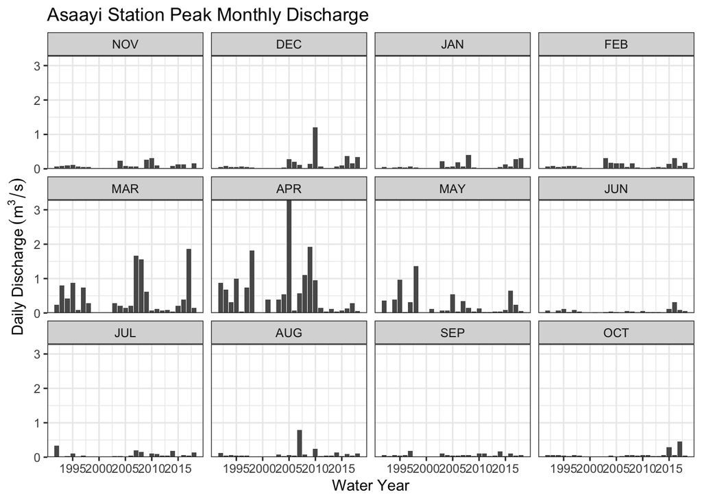

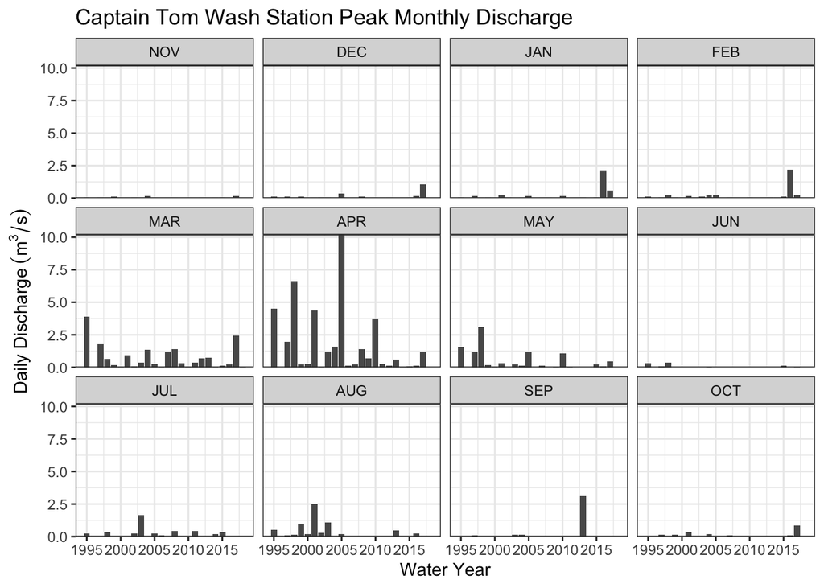

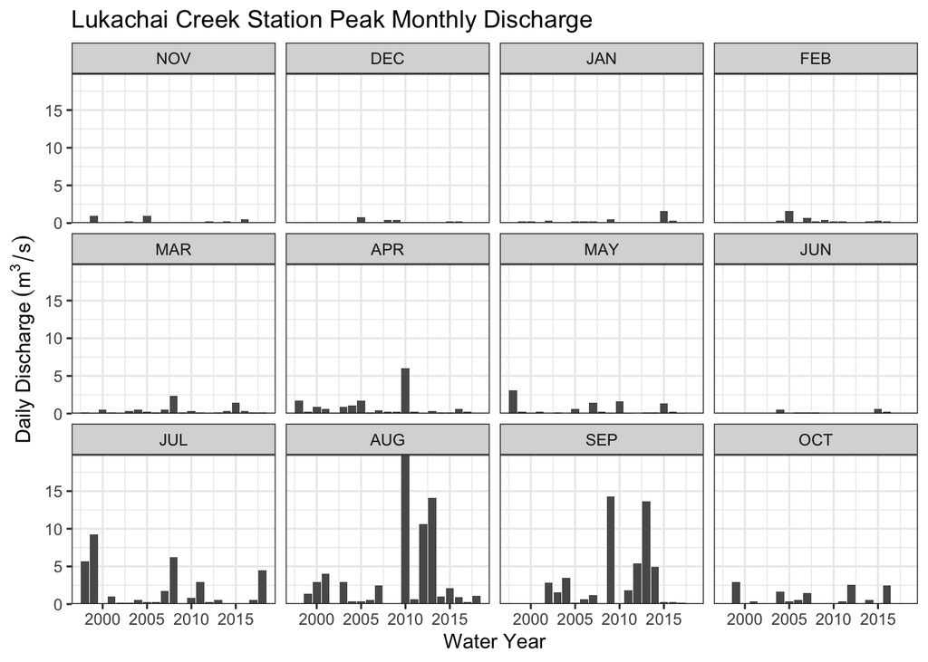

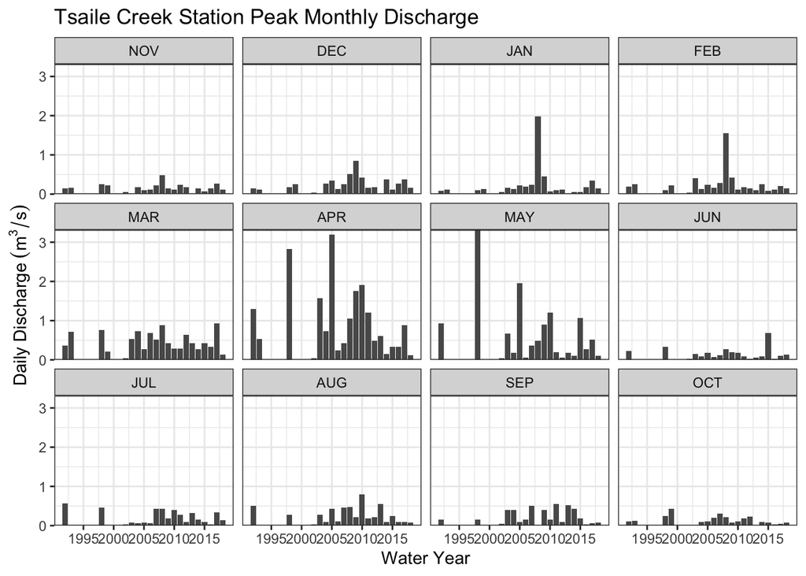

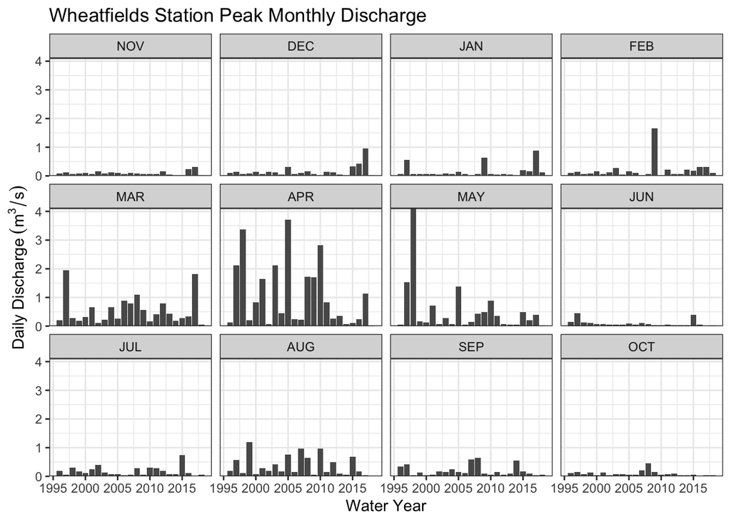

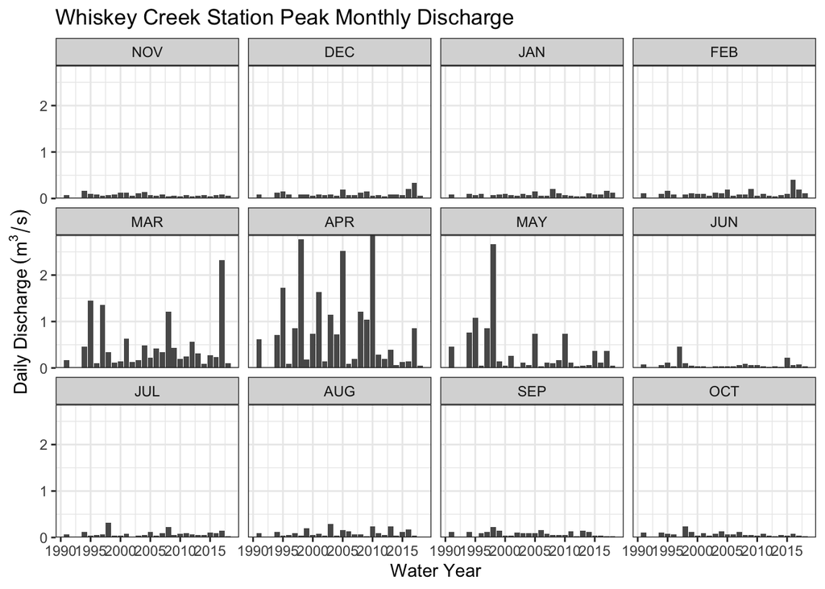

All of the station usually have peak streamflow in April EXCEPT Lukachai, which has it’s peak streamflow in August. Maybe Lukachai depends more on summer monsoons while the others are more dominated by snowpack.

# Seasonal streamflow

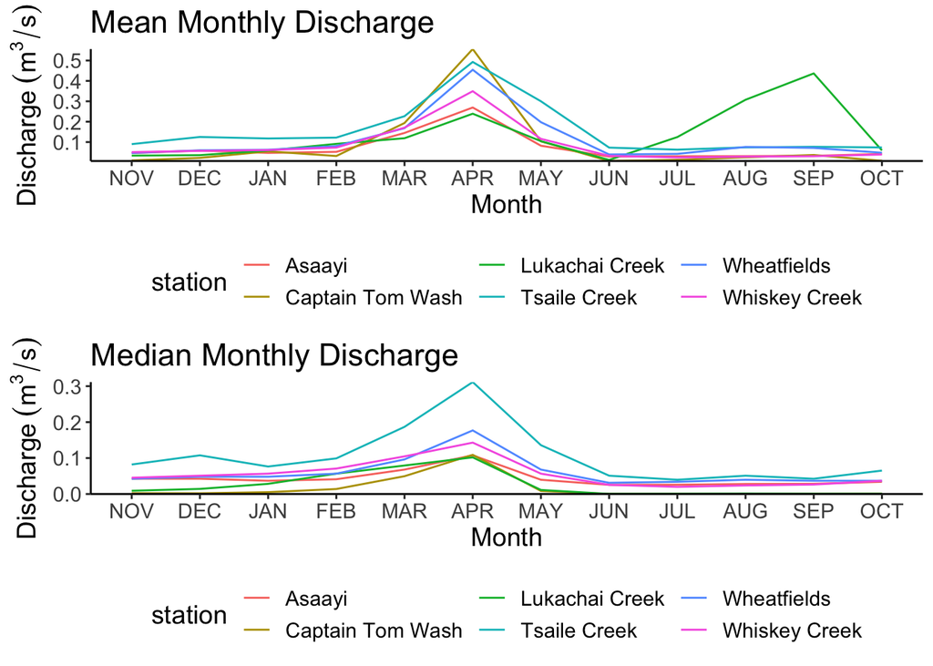

#### Observations

Mean seasonal monthly discharge shows the expected increase in flow in the summer for Lukachai and Captain Tom was having the higest discharge in the spring. However, this changes when we look at median discharge. This may mean Lukachai’s flow is more dominated by Monsoon activity than snowpack.

# Correlations between stations

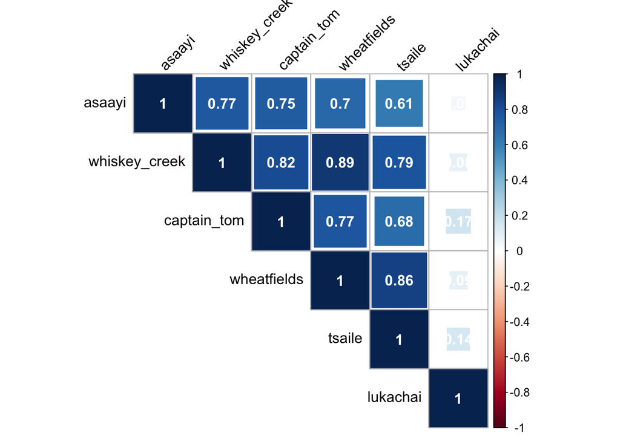

## compare to Whiskey Creek Snotel Station

### compare time series of snotel swe and streamflow

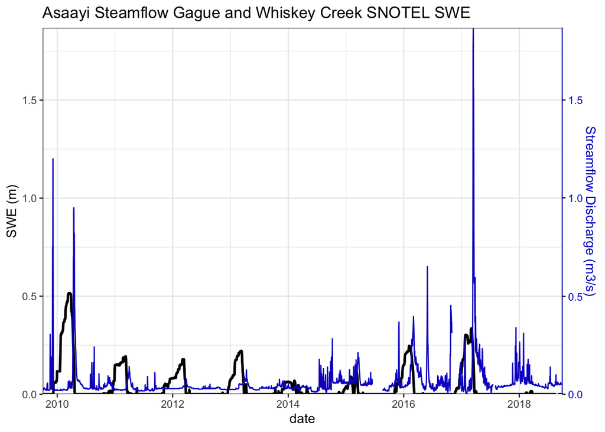

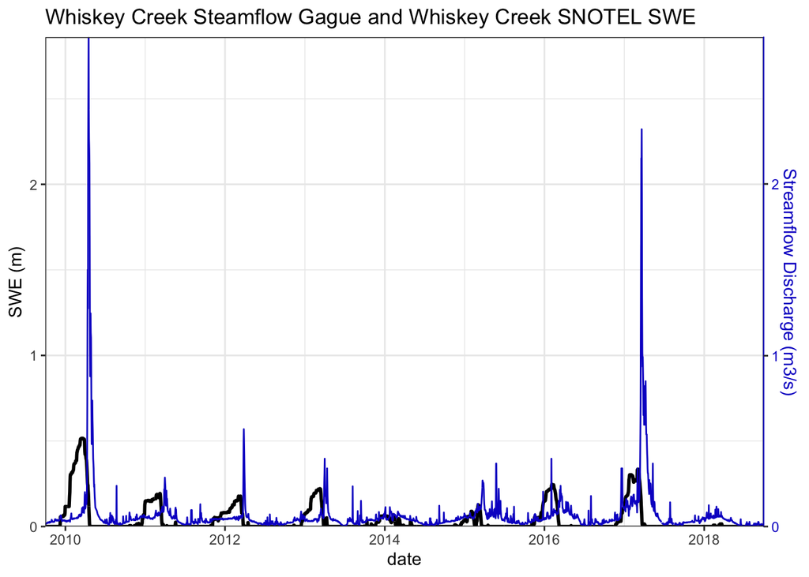

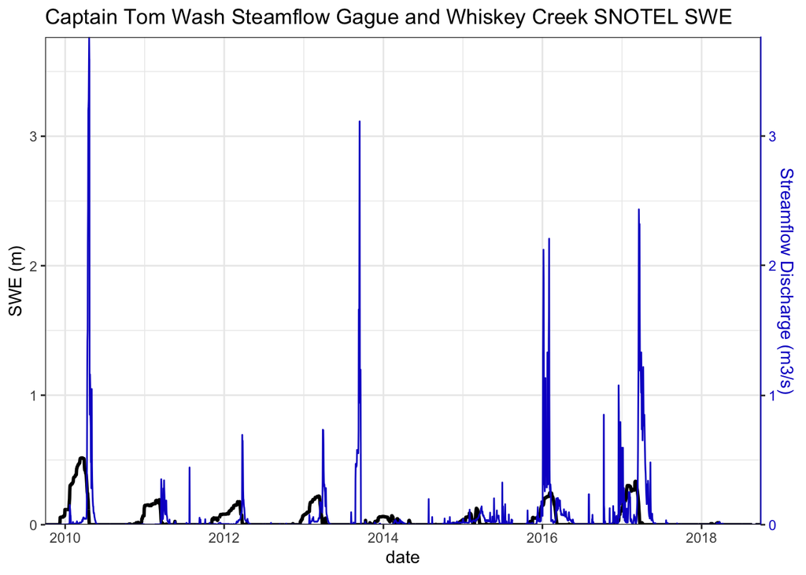

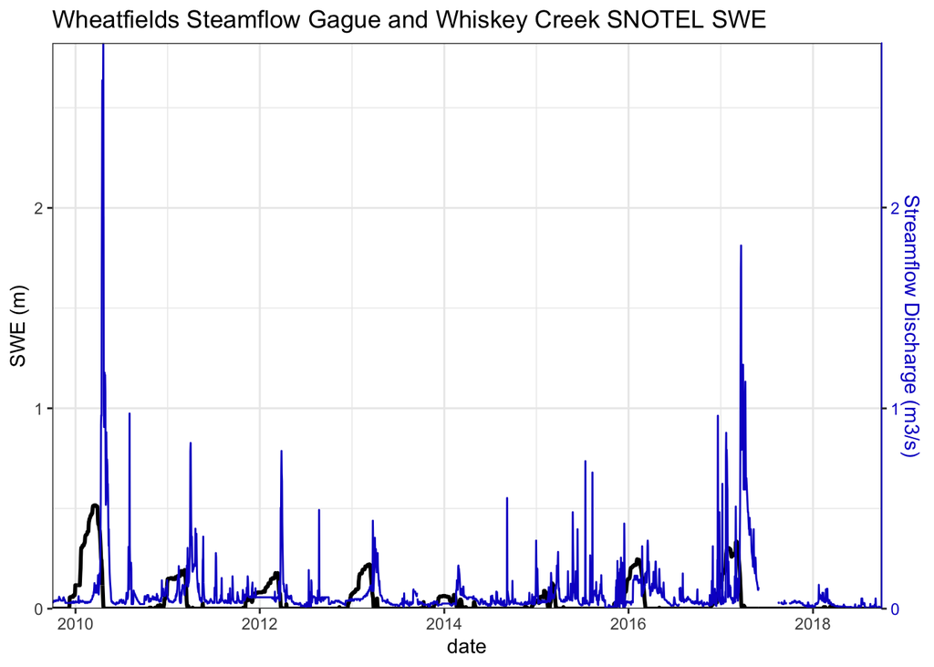

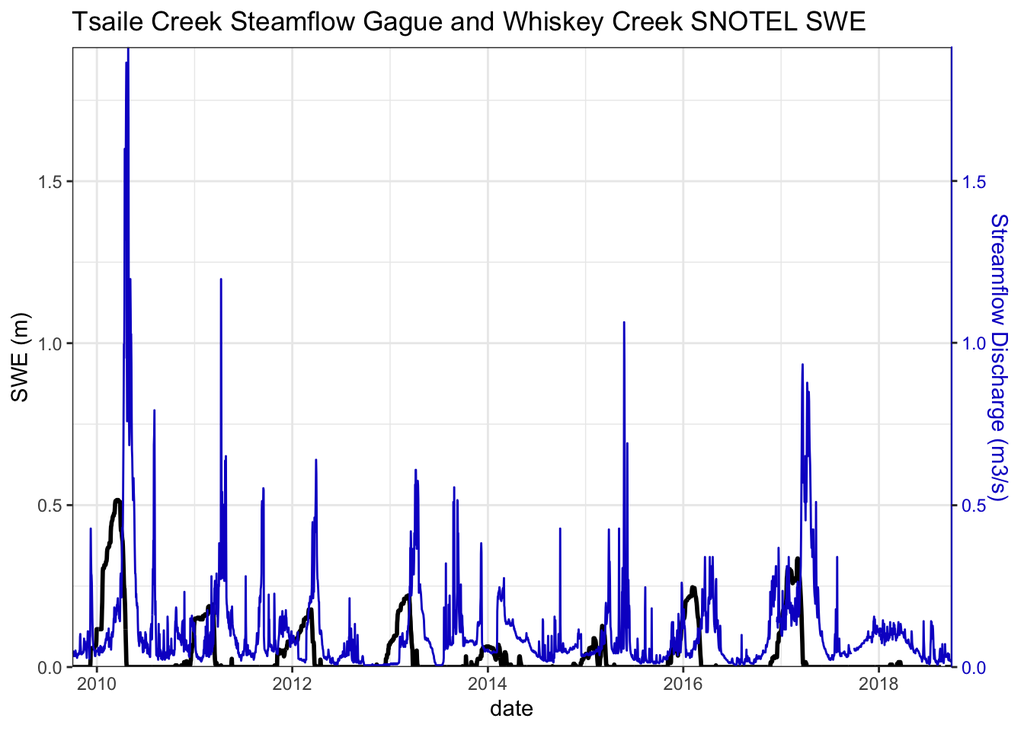

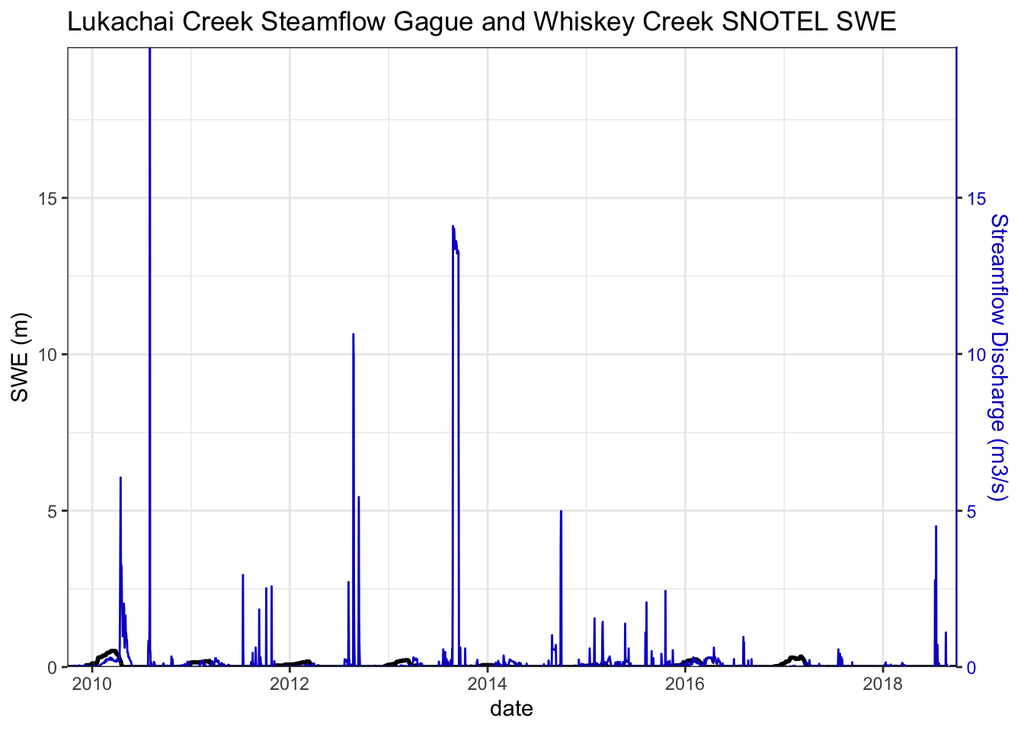

### Compare SNOTEL peak SWE rank order with yearly summed streamflow rank order

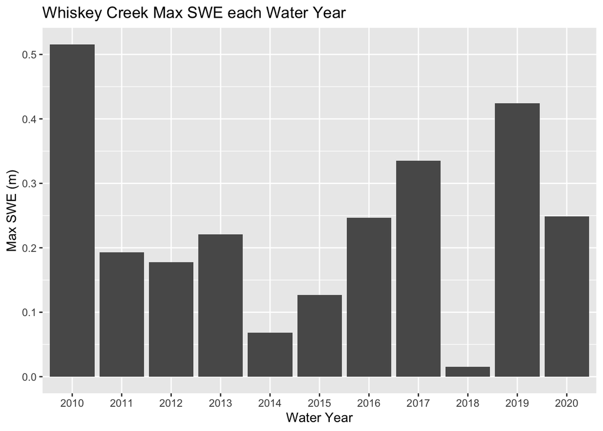

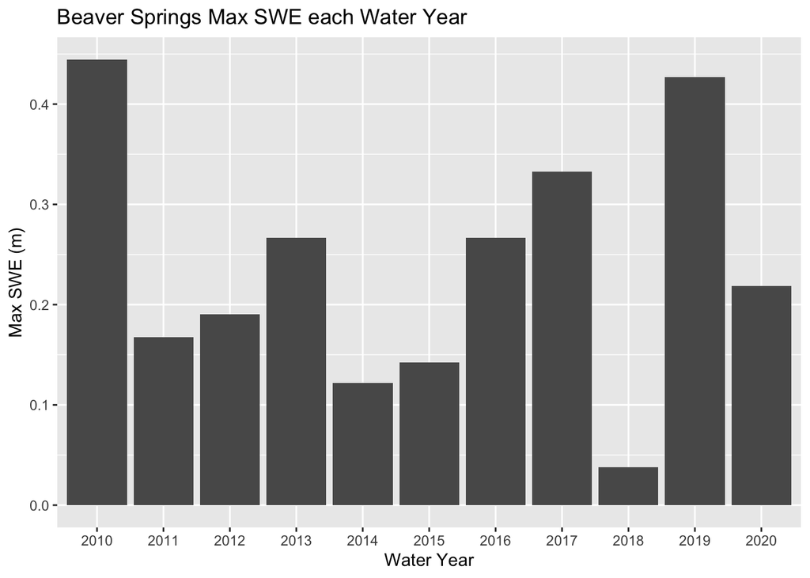

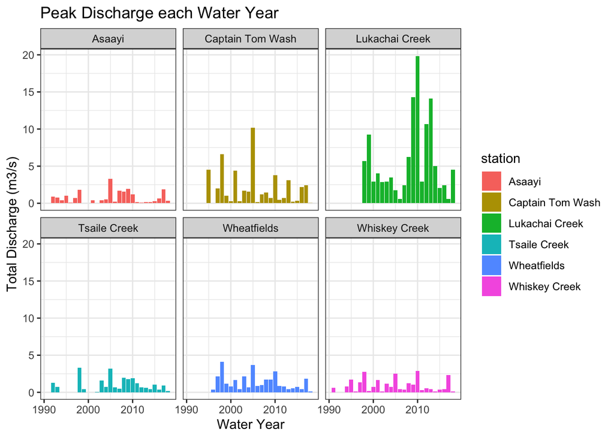

### Compare peak discharge rank to snotel peak swe rank

The ranks of peak discharge per water year and maximum SWE are **not** statistically different for Whiskey Creek Snotel and Asaayi and Whiskey Creek Stream

The ranks of peak discharge per water year and maximum SWE **are** statistically different for Whiskey Creek Snotel Captain Tom Wash, Wheatfields, Tsaile, Lukachai

The ranks of peak discharge per water year and maximum SWE are **not** statistically different for Beaver Springs Snotel and Asaayi and Whiskey Creek Stream

The ranks of peak discharge per water year and maximum SWE **are** statistically different for Beaver Springs Snotel Captain Tom Wash, Wheatfields, Tsaile, Lukachai